# DARE-4

Seulbi Lee, Havi Khurana, Janette Avelar

2024-03-03

```r
#Load package and read data
library(haven)
library(tidyverse)
library(kableExtra)
library(fixest)
library(MatchIt)
library(modelsummary)
library(here)

# read data
dat <- read_dta(here("DARE-4", "dumont_umansky_ECLSK.dta"))
```

#### A1.

The table shows counts and means of standardized teacher perceptions of student skills by English Learner (EL) program participation. For non-EL students, the average perceived skills in language are at 0.061 and in math at 0.073, indicating slightly above neutral or average perception. For EL students, the average perceived skills in language are at -0.392 and in math at -0.292, indicating a below-average perception. Figure 1 describes the distribution of standardized teacher perception scores for the two student groups, which are both left-skewed and have similar variance. It is evident that teachers perception scores are different for EL and non-EL students. The negative values for EL students suggest a perception of below-average abilities, while the positive values for non-EL students suggest a perception of above-average abilities.

However, this evidence should not be interpreted as a plausibly causal estimate of the effect of being classified as an EL student on teachers’ perceptions because the data does not control for other variables that might influence teacher perceptions (such as student’s proficiency in the subject-matter).

```r
#summary(dat)

summary_table_a1 <- dat |>
  group_by(elprgm) |>
  summarise('N' = n(),
            'Language Skills'= round(mean(tlangk) , 3), 'Math Skills' = round(mean(tmathk) , 3)) |>
    mutate(elprgm = if_else(elprgm == 1, "EL", "Non EL")) |>
    rename('EL Status' = elprgm)

table_a1 <- kable(summary_table_a1, format = "html", caption = "Table 1. Summary of Teacher Perceptions of Student Skills by English Learner Program Participation", align = c('l', 'r', 'r', 'r')) |>
  kable_styling(bootstrap_options = c("striped", "hover"), full_width = F, position = "center") |>
  column_spec(1, bold = T)

table_a1
```

Table 1. Summary of Teacher Perceptions of Student Skills by English Learner Program Participation

| EL Status | N | Language Skills | Math Skills |
| --- | --- | --- | --- |
| Non EL | 945 | 0.061 | 0.073 |
| EL | 1221 | -0.392 | -0.292 |

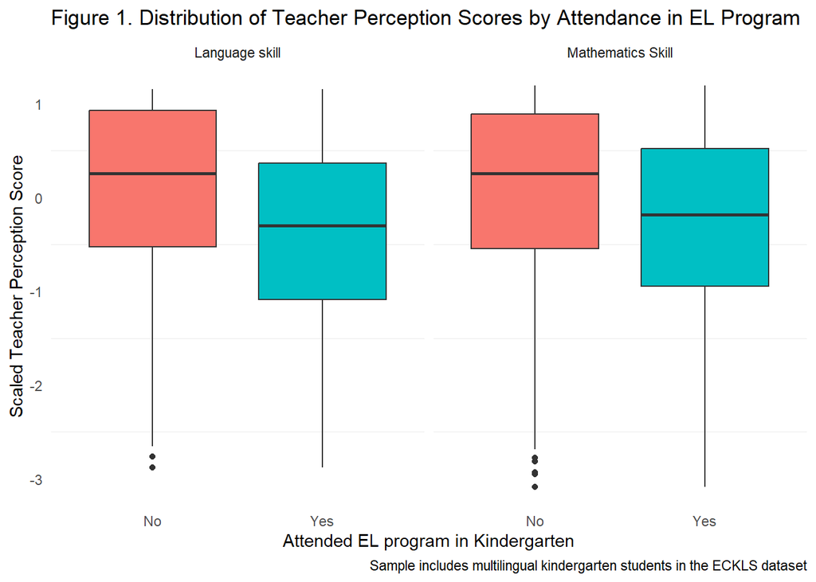

```r
#Figure 1
dat %>%
  pivot_longer(cols = c(tlangk, tmathk),
               names_to = "skill",
               values_to = "score",
               names_prefix = "t") %>%
  mutate(skill = ifelse(skill == "langk", "Language skill", "Mathematics Skill")) %>%
  ggplot() +
  geom_boxplot(aes(x = factor(elprgm), y = score, fill = factor(elprgm)),
               show.legend = F) +
  scale_x_discrete(labels = c("No", "Yes")) +
  labs(x = "Attended EL program in Kindergarten",
       y = "Scaled Teacher Perception Score",
       fill = "",
       title = "Figure 1. Distribution of Teacher Perception Scores by Attendance in EL Program",
       caption = "Sample includes multilingual kindergarten students in the ECKLS dataset")+
  facet_wrap(~skill) +
  theme_minimal()+
  theme(panel.grid.major  = element_blank())
```

#### A2.

```r
full_sample_summary <- dat |>
  summarise(
    'Family SES (standardized)' = mean(ses, na.rm = TRUE),
    Female = mean(female, na.rm = TRUE) * 100,
    'Hispanic/Latinx' =  mean(hisp, na.rm = TRUE) * 100,
    'Chronically absent in kindergarten' = mean(chrabsk, na.rm = TRUE) * 100,
    'Rural location' = mean(rural, na.rm = TRUE) * 100,
    'Executive function' = mean(kexecfunc1, na.rm = TRUE),
    'Preschool Language Assessment Scale' = mean(prelas, na.rm = TRUE),
    'English Basic Reading Skill' = mean(ebrs, na.rm = TRUE),
    'Reading assessment' = mean(kread, na.rm = TRUE),
    'Math assessment' = mean(kmath, na.rm = TRUE),
    'Teacher Experience' = mean(tchrexp, na.rm = TRUE)
  ) |>
  mutate(Group = "Full Sample")

el_summary <- dat |>
  group_by(elprgm) |>
  summarise(
    'Family SES (standardized)' = mean(ses, na.rm = TRUE),
    Female = mean(female, na.rm = TRUE) * 100,
    'Hispanic/Latinx' =  mean(hisp, na.rm = TRUE) * 100,
    'Chronically absent in kindergarten' = mean(chrabsk, na.rm = TRUE) * 100,
    'Rural location' = mean(rural, na.rm = TRUE) * 100,
    'Executive function' = mean(kexecfunc1, na.rm = TRUE),
    'Preschool Language Assessment Scale' = mean(prelas, na.rm = TRUE),
    'English Basic Reading Skill' = mean(ebrs, na.rm = TRUE),
    'Reading assessment' = mean(kread, na.rm = TRUE),
    'Math assessment' = mean(kmath, na.rm = TRUE),
    'Teacher Experience' = mean(tchrexp, na.rm = TRUE)
  ) |>
  mutate(Group = if_else(elprgm == 1, "EL", "Non-EL")) |>
  ungroup() |>
    select(-elprgm)

combined_summary <- full_sample_summary |>
  bind_rows(el_summary) |>
  pivot_longer(cols = -Group, names_to = "Measure", values_to = "Value")

combined_summary_wide <- combined_summary |>
  pivot_wider(names_from = Group, values_from = Value)

combined_summary_wide <- combined_summary_wide |>
  slice(-10) |>
  mutate(across(c(`Full Sample`, `Non-EL`, `EL`), ~ case_when(
    Measure %in% c("Female", "Chronically absent in kindergarten", "Rural location", "Hispanic/Latinx") ~ paste0(sprintf("%.2f", round(., 2)), "%"),
    TRUE ~ sprintf("%.2f", round(., 2))
  )))

table_a2 <- kable(combined_summary_wide, format = "html",
                  caption = "Table 2. Comparisons of Student and School Characteristics and Test Scores Between Full Sample, EL, and Non-EL Students") |>
  kable_styling(
    bootstrap_options = c("striped", "hover"),
    full_width = F,
    position = "center"
  )

table_a2
```

Table 2. Comparisons of Student and School Characteristics and Test Scores Between Full Sample, EL, and Non-EL Students

| Measure | Full Sample | Non-EL | EL |
| --- | --- | --- | --- |
| Family SES (standardized) | -0.48 | -0.21 | -0.69 |
| Female | 49.86% | 50.90% | 49.06% |
| Hispanic/Latinx | 63.90% | 50.05% | 74.61% |
| Chronically absent in kindergarten | 11.08% | 12.80% | 9.75% |
| Rural location | 10.57% | 13.76% | 8.11% |
| Executive function | 13.49 | 14.17 | 12.97 |
| Preschool Language Assessment Scale | 15.89 | 17.62 | 14.55 |
| English Basic Reading Skill | 11.94 | 13.41 | 10.79 |
| Reading assessment | -0.80 | -0.49 | -1.03 |
| Teacher Experience | 13.55 | 13.48 | 13.60 |

#### B1.

To estimate the probability that a student who lives in a home where a language other than English is spoken will be identified as an English learner, we used the following model:

$$P(EL_i) = \beta_0 + \beta_1PreLAS_i +
\beta_2 EBRS_i + \beta_3SES_i + \beta_4RURAL_i + \beta_5Female_i +
\beta_6HISP_i + \epsilon_i$$

Figure 2 shows our region of common support prior to matching. The amount of overlap we see in the histograms indicates that our EL and non-EL groups in the full sample have comparable distributions of the probability scores derived from the key matching variables. Thus, we would be successful in matching across variables without losing much sample size, and feel that our comparison across these groups will result in a reliable estimate.

```r
dat <- dat |>
  mutate(
    race = as.factor(race),
#   elprgm = as.factor(elprgm),
    female = as.factor(female),
    rural = as.factor(rural),
    hisp = as.factor(hisp)
  )
```

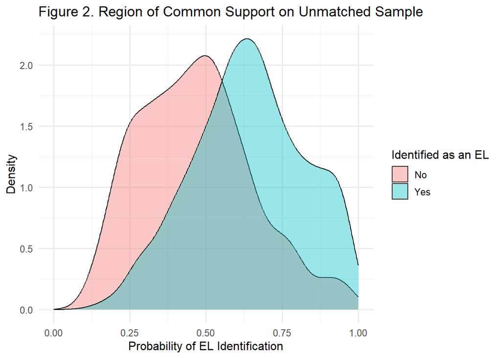

```r
# 1. Fit logistic selection model estimating probability of home language, given covariates
pscores <- feglm(elprgm ~ prelas + ebrs + ses + rural + female + hisp, family=c("logit"), data=dat)

#summary(pscores)

# 2. Estimate fitted probability of selection into treatment for each individual
dat$p_score <- predict(pscores, type = "response")

#head(pscore_df)

# 3. Examine common support
ggplot(dat, aes(p_score, fill = as.factor(elprgm))) +
  geom_density(alpha=0.4) +
  theme_minimal(base_size = 12) +
  labs(x = "Probability of EL Identification",
       fill = "Identified as an EL",
       title = "Figure 2. Region of Common Support on Unmatched Sample",
       y = "Density") +
  scale_fill_discrete(labels = c("No", "Yes"))+
  scale_x_continuous(limits = c(0,1))
```